### Richard Safran Student ID: 998862635

# Assignment 6

In this assignment, you'll analyze a collection of data sets from the [San Francisco Open Data Portal](http://data.sfgov.org/) and [Zillow](https://www.zillow.com/). The data sets have been stored in the SQLite database `sf_data.sqlite`, which you can [download here](http://anson.ucdavis.edu/~nulle/sf_data.sqlite). The database contains the following tables:

| Table | Description |
| --- | --- |
| `crime` | Crime reports dating back to 2010. |
| `mobile_food_locations` | List of all locations where mobile food vendors sell. |
| `mobile_food_permits` | List of all mobile food vendor permits. More details [here](https://data.sfgov.org/api/views/rqzj-sfat/files/8g2f5RV4PEk0_b24iJEtgEet9gnh_eA27GlqoOjjK4k?download=true&filename=DPW_DataDictionary_Mobil… |
| `mobile_food_schedule` | Schedules for mobile food vendors. |
| `noise` | Noise complaints dating back to August 2015. |
| `parking` | List of all parking lots. |
| `parks` | List of all parks. |
| `schools` | List of all schools. |
| `zillow` | Zillow rent and housing statistics dating back to 1996. More details [here](https://www.zillow.com/research/data/). |

The `mobile_food_` tables are explicitly connected through the `locationid` and `permit` columns. The other tables are not connected, but you may be able to connect them using dates, latitude/longitude, or postal codes.

Shapefiles for US postal codes are available [here](https://www.census.gov/geo/maps-data/data/cbf/cbf_zcta.html). These may be useful for converting latitude/longitude to postal codes.

Shapefiles for San Francisco Neighborhoods are available [here](https://data.sfgov.org/Geographic-Locations-and-Boundaries/SF-Find-Neighborhoods/pty2-tcw4).

```python
#Important Basic Packages
import sqlite3 as sql
import pandas as pd
import numpy as np

#Plotting Related Packages
import matplotlib.pyplot as plt
%matplotlib inline
plt.rcParams['figure.figsize'] = (12, 12)

#Mapping Related Packages
from mpl_toolkits.basemap import Basemap
import seaborn as sns
import geopandas as gpd
import shapely.geometry as geom
```

```python
#Load the data
db = sql.connect("sf_data.sqlite")

#Look at the database
pd.read_sql("SELECT * FROM sqlite_master", db)
```

|  | type | name | tbl_name | rootpage | sql |
| --- | --- | --- | --- | --- | --- |
| 0 | table | crime | crime | 2 | CREATE TABLE "crime" (\n"IncidntNum" INTEGER,\... |
| 1 | table | noise | noise | 35775 | CREATE TABLE "noise" (\n"CaseID" INTEGER,\n "... |
| 2 | table | parking | parking | 35921 | CREATE TABLE "parking" (\n"Owner" TEXT,\n "Ad... |
| 3 | table | schools | schools | 35944 | CREATE TABLE "schools" (\n"Name" TEXT,\n "Ent... |
| 4 | table | parks | parks | 35961 | CREATE TABLE "parks" (\n"Name" TEXT,\n "Type"... |
| 5 | table | zillow | zillow | 35967 | CREATE TABLE "zillow" (\n"RegionName" INTEGER,... |
| 6 | table | mobile_food_permits | mobile_food_permits | 36050 | CREATE TABLE "mobile_food_permits" (\n"permit"... |
| 7 | table | mobile_food_locations | mobile_food_locations | 36060 | CREATE TABLE "mobile_food_locations" (\n"locat... |
| 8 | table | mobile_food_schedule | mobile_food_schedule | 36079 | CREATE TABLE "mobile_food_schedule" (\n"locati... |

**Exercise 1.1.** Which mobile food vendor(s) sells at the most locations?

```python
#Use the mobile_food_locations, mobile_food_schedule, and mobile_food_permits to get the permit id, address id, and applicant name for all unique approved permits.
question1_sql = pd.read_sql("SELECT DISTINCT permit.Applicant, location.Address, schedule.permit \
                             FROM mobile_food_locations location \
                             INNER JOIN mobile_food_schedule schedule ON location.locationid = schedule.locationid \
                             INNER JOIN mobile_food_permits permit ON schedule.permit = permit.permit \
                             WHERE permit.Status=='APPROVED'", db)

#Grab the counts in the pandas dataframe for the applicant column. Rename to unique locations
most_locations = pd.DataFrame(question1_sql.Applicant.value_counts())
most_locations.columns = ["Unique Locations"]
most_locations.head()
```

|  | Unique Locations |
| --- | --- |
| Park's Catering | 23 |
| D & T Catering | 17 |
| F & C Catering | 13 |
| Munch A Bunch | 10 |
| Eva's Catering | 8 |

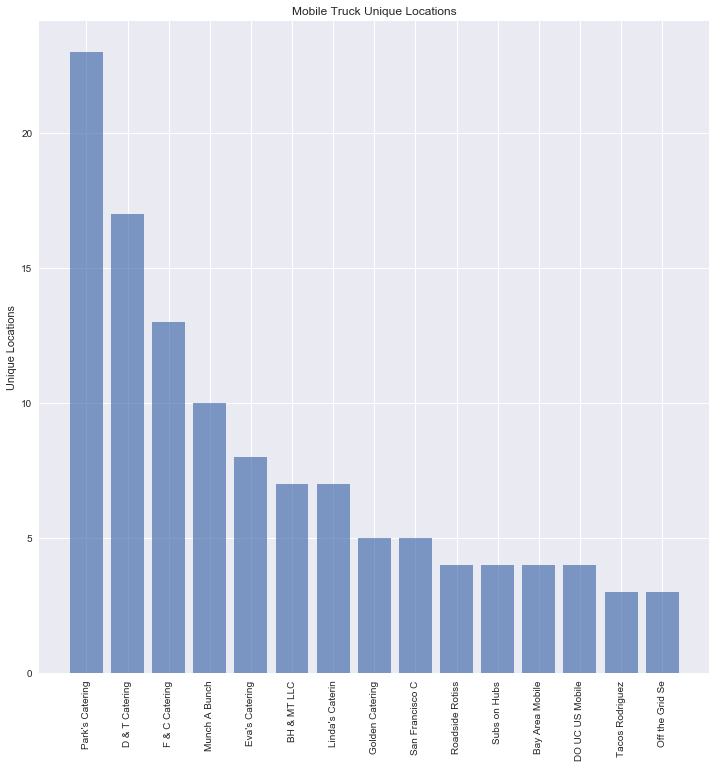

```python
#Set up the x axis values with names saved to a list and a position for the inital graph.
objects = list(most_locations.index.values)[:15]
objects_abb = [name[:15] for name in objects]
y_pos = np.arange(len(objects))

#Plot the data
plt.bar(y_pos, most_locations["Unique Locations"][:15],alpha=0.7)

#Set up the graphs
plt.xticks(y_pos, objects_abb, rotation = 'vertical')
plt.ylabel('Unique Locations')
plt.title('Mobile Truck Unique Locations')
plt.show()
```

The graph above contains the fifteen food trucks found at the most location. The street car with the most locations is Park's Catering with 23 uinque locations. D&T Catering has the 2nd most unique locations at 17 and F&C catering has the 3rd most unique locations at 13. There is only four food trucks with double digit amount of unique locations. Therefore, there appears to be some consolidation in the foodtruck market with a couple dominant mobile food truck providers. Besides these top providers there is a large amount of mid-tier to small food truck providers that are found between 1-10 locations.

## __Exercise 1.2.__ Ask and use the database to analyze 5 questions about San Francisco. For each question, write at least 150 words and support your answer with plots. Make a map for at least 2 of the 5 questions.

### Question 1: Which parts of the city are the most and least expensive?

```python
zillow_ungrouped = pd.read_sql("SELECT * FROM zillow WHERE MedianSoldPricePerSqft_AllHomes != 'NaN'",db)
```

```python
#Query to acquire the Median Price Per Sq Ft and the zipcodes so that each zipcode has the average Median Price Per Sq Ft.
med_price = pd.read_sql("SELECT RegionName AS 'Zipcode', MedianSoldPricePerSqft_AllHomes AS 'Median Price Per Sq ft' FROM Zillow \
                        WHERE MedianSoldPricePerSqft_AllHomes != 'NaN' \
                        GROUP BY Zipcode \
                        ORDER BY MedianSoldPricePerSqft_AllHomes DESC", db)
med_price.head()
```

|  | Zipcode | Median Price Per Sq ft |
| --- | --- | --- |
| 0 | 94104 | 1336.128581 |
| 1 | 94111 | 901.804100 |
| 2 | 94133 | 850.666667 |
| 3 | 94123 | 836.363636 |
| 4 | 94117 | 777.939300 |

```python
#Acquire the overall median sold price in all zipcodes.
overall_med = np.median(zillow_ungrouped["MedianSoldPricePerSqft_AllHomes"])

#Create another column that compares the zipcode's Median Price Per Sq ft to that of all of SF
med_price['Diff to SF Median'] = [row - overall_med for row in med_price['Median Price Per Sq ft']]
```

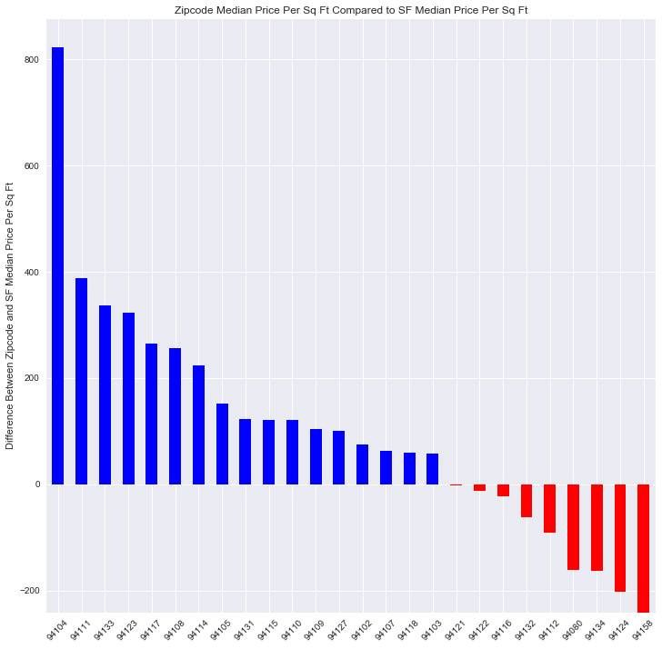

```python
#Graph the Difference of the Median Price Per Sq Ft to that of SF based on each zip code.
x_axis = med_price['Zipcode']
y_pos = np.arange(len(x_axis))

#Change the color to have distinct above the median and below the median values
mask = med_price['Diff to SF Median'] <= 0
colors = np.array(['blue']*len(med_price['Diff to SF Median']))
colors[mask.values] = 'red'

#Create the graph
med_price['Diff to SF Median'].plot(kind = 'bar', color = colors)
plt.title('Zipcode Median Price Per Sq Ft Compared to SF Median Price Per Sq Ft')
plt.xticks(y_pos, x_axis, rotation = 45)
plt.ylabel('Difference Between Zipcode and SF Median Price Per Sq Ft')
plt.show()
```

```python
#Based on the graph 4 distinct most expensive and least expensive zipcodes.
extremes = med_price[:4].append(med_price[-4:])
extremes
```

|  | Zipcode | Median Price Per Sq ft | Diff to SF Median |
| --- | --- | --- | --- |
| 0 | 94104 | 1336.128581 | 822.188793 |
| 1 | 94111 | 901.804100 | 387.864312 |
| 2 | 94133 | 850.666667 | 336.726878 |
| 3 | 94123 | 836.363636 | 322.423848 |
| 22 | 94080 | 353.344500 | -160.595288 |
| 23 | 94134 | 351.758200 | -162.181588 |
| 24 | 94124 | 312.412600 | -201.527188 |
| 25 | 94158 | 273.033708 | -240.906080 |

```python
#Zipcodes of interest to look through the zipcode database for
zipcodes_int = [str(x) for x in med_price["Zipcode"].values]
```

```python
#Read in the zip code database
SF_zips = gpd.read_file("/Users/Ricky/Desktop/cb_2015_us_zcta510_500k-final/cb_2015_us_zcta510_500k.shp")
```

```python
#Look for the zipcodes within SF found withing the list above and take the two columns of interest.
SF_zips = SF_zips.loc[SF_zips["ZCTA5CE10"].isin(set(zipcodes_int))]
SF_zips = SF_zips.sort("ZCTA5CE10").reset_index(drop=True)
SF_zips = SF_zips[["ZCTA5CE10", "geometry"]]

#Reset the index to prepare to merge with the other dataframe.
med_price = med_price.sort("Zipcode").reset_index(drop=True)

#Merge the two dataframes based on the sorted zipcodes. Want to get the polygon and the price on the same data frame.
df_merged = pd.concat([SF_zips, med_price["Median Price Per Sq ft"]], axis=1)
```

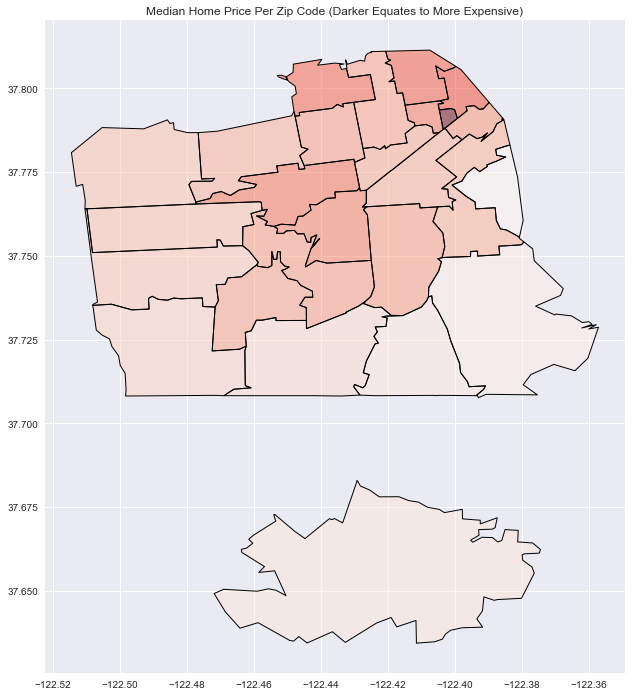

```python
#Create the plot where darker color means more expensive.
df_merged.plot(column='Median Price Per Sq ft', colormap="Reds")
plt.title("Median Home Price Per Zip Code (Darker Equates to More Expensive)")
```

For the purposes of the report I am including South San Francisco as part of San Francisco. San Francisco housing prices vary distinctly depending on their location. Just examining the shaded map plot it is apparent that the more north and east the housing is located within San Francisco the more expensive houses becomes.

Top four most expensive districts (Most expensive to less):

- 94104 (Financial District)
- 94111 (Jackson Square)
- 94133 (North Beach/Chinatown)
- 94123 (Marina)

A common theme for the most expensive districts is there close proximity to the business hubs of San Francisco and the nicer and more toursity ports located in San Francisco. This makes sense that these are the most expensive due to both the convienance of traveling to work and prime destination spots. Additionally, these districts are primarily offices meaning that there would be a shortage of supply for housing, driving prices up. This is especially prevalent in the financial district where the price per square foot is over 400 more than the next highest, jackson square.

The four least expensive districts (Least expensive to more):

- 94158 (Mission District)
- 94124 (Bayview-Hunters Point)
- 94134 (Visitacion Valley/Sunnydale)
- 94080 (South San Francisco)

The lease expensive regions are located in the sketchy portions of San Francisco in the underdeveloped and notorious crime heavy areas. These areas are not particularly close to popular travel destinations which are located in north San Francisco. Additionally, large parts of this section of the city are rundown, where it is not uncommon for certain houses to be boarded up. Therefore, there is low demand to live in this location and there is excess supply driving the prices down.

Another interesting in the comparison of the median housing prices per district to all of San Francisco in the bar graph above was that a majority of districts (all but 9) had a median housing price per sq ft above that of all of San Francisco. This means that there is more housing in the cheaper parts of the city than in the more expensive areas. This could be a result of more housing driving the prices down from an economics point of view. Another reason could be there being speicifc business and residential areas in San Francisco, so finding housing outside of a residential zone could drive the price up.